# README

Author

Yingxin Xu

Published

March 15, 2024

# Get libs

```r
pacman::p_load(tidyverse, targets, gt, readxl, cowplot)
```

# Clean data

Data cleaning, including the following steps

(The reason for placing the deletion of NA rows as the last step is that the majority of missing values occur in the ‘runtime_minutes’ column. However, this column does not affect our judgment of the highest-rated movie genres. Therefore, the choice is to extract the necessary data columns before removing the missing values.)

1. Select data rows where “movie_type” is either ‘movie’ or ‘tvMovie’ (tvMovie is also considered as movie).
2. Select rows where “Christmas” is TRUE.
3. Extract columns: primary_title, genres, average_rating, num_votes, and store them in the movie_clean data frame.
4. Delete rows in the data that contain NA values.
5. Sort data by avarage rating in descending order.

This is the cleaned data after the process:

```r
tar_read(movie_clean)
```

```
# A tibble: 1,683 × 4
   primary_title                                 genres average_rating num_votes
   <chr>                                         <chr>           <dbl>     <dbl>
 1 Bringing Back Christmas                       Family            9.9        20
 2 Cheap vs. Expensive Xmas Day                  Comedy            9.5        14
 3 Marie Osmond's Merry Christmas                Famil…            9.4        23
 4 Christmas and the Civil War                   Docum…            9.3        16
 5 Tom's Christmas Tree                          Family            9.2        34
 6 Christmas Ringer                              Roman…            9.2        21
 7 Let's Go Luna!: Luna's Christmas Around the … Anima…            9.2        18
 8 EastEnders: Christmas Party                   Comed…            9          18
 9 EastEnders Christmas Fall Outs                Docum…            9          11
10 A Baby Reindeer's First Christmas             Docum…            9          10
# ℹ 1,673 more rows
```

# Expanding Genres

Many movies belong to multiple genres at the same time. To analyse each genre individually, we have split the data of movies that belong to multiple genres into multiple rows. For instance, if a movie belongs to the Adventure, Crime, and Romance genres, the data for that movie is split into three rows. The “genres” entry for each of the three rows is Adventure, Crime, and Romance, respectively. The remaining data in primary_title, average_rating, and num_votes remains the same.

This approach allows us to calculate separate statistics such as the mean and median of average rating for each genre.

Below is the data obtained after splitting the genres entry.

```r
tar_read(movie_unlisted)
```

```
# A tibble: 3,395 × 4
   primary_title                                 genres average_rating num_votes
   <chr>                                         <chr>           <dbl>     <dbl>
 1 Bringing Back Christmas                       Family            9.9        20
 2 Cheap vs. Expensive Xmas Day                  Comedy            9.5        14
 3 Marie Osmond's Merry Christmas                Family            9.4        23
 4 Marie Osmond's Merry Christmas                Music             9.4        23
 5 Christmas and the Civil War                   Docum…            9.3        16
 6 Christmas and the Civil War                   Histo…            9.3        16
 7 Christmas and the Civil War                   War               9.3        16
 8 Tom's Christmas Tree                          Family            9.2        34
 9 Christmas Ringer                              Roman…            9.2        21
10 Let's Go Luna!: Luna's Christmas Around the … Anima…            9.2        18
# ℹ 3,385 more rows
```

# Mean and Median Ratings for Each Genre

To identify the genre with the highest average rating, we examined the mean ratings for each genre. To mitigate the impact of skewness on our assessment, we also calculated the median ratings for each genre and generated box plots.

```r
tar_read(movie_mean) # get mean rating for each genre and sort decreasingly
```

```
# A tibble: 23 × 2
   genres      mean_average_rating
   <chr>                     <dbl>
 1 History                    7.4
 2 Documentary                7.17
 3 War                        6.96
 4 Music                      6.85
 5 Biography                  6.84
 6 News                       6.6
 7 Film-Noir                  6.5
 8 Animation                  6.50
 9 Musical                    6.43
10 Sci-Fi                     6.1
# ℹ 13 more rows
```

```r
tar_read(movie_median) # get median rating for each genre and sort decreasingly
```

```
# A tibble: 23 × 2
   genres      median_average_rating
   <chr>                       <dbl>
 1 History                      7.65
 2 Documentary                  7.3
 3 War                          7.1
 4 Biography                    7
 5 Animation                    6.7
 6 Musical                      6.65
 7 Music                        6.6
 8 News                         6.6
 9 Film-Noir                    6.5
10 Sci-Fi                       6.45
# ℹ 13 more rows
```

```r
tar_read(genre_maxmean) # select the top three genres with the highest mean ratings
```

```
# A tibble: 3 × 2
  genres      mean_average_rating
  <chr>                     <dbl>
1 History                    7.4
2 Documentary                7.17
3 War                        6.96
```

```r
tar_read(genre_maxmedian) # select the top three genres with the highest median ratings
```

```
# A tibble: 3 × 2
  genres      median_average_rating
  <chr>                       <dbl>
1 History                      7.65
2 Documentary                  7.3
3 War                          7.1
```

# Boxplot and Table

Now, let’s draw box plots to show how ratings are spread across different genres.

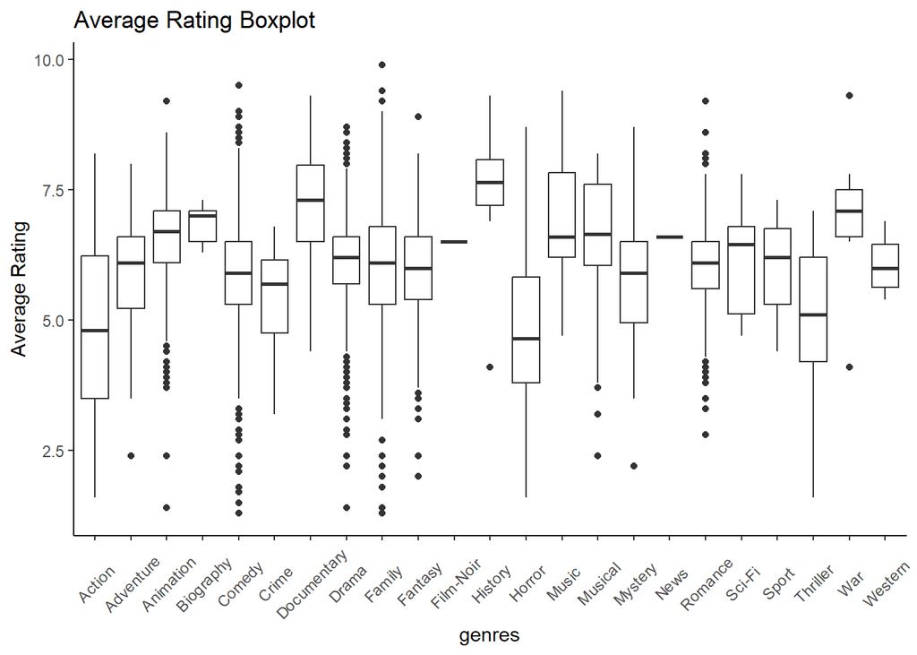

```r
tar_read(boxplot_movie)
```

Next, let’s take a look at how many movies there are in each genre.

```r
tar_read(table_genre)
```

```
  Film-Noir        News       Sport     Western   Biography         War
          1           1           3           4           5           7
    History      Sci-Fi       Crime      Action    Thriller     Mystery
          8          10          19          20          21          23
    Musical      Horror Documentary       Music   Adventure     Fantasy
         44          48          54          56          86         161
  Animation      Family     Romance       Drama      Comedy
        162         551         636         697         778
```

Looking at both the boxplot and the table, we can see that there’s a big difference in the number of movies across various genres. Although History has the highest mean and median ratings, it doesn’t have many movies in the dataset. On the other hand, genres like Comedy, Drama, Romance, and Family have a lot of Christmas movies.

It’s worth noting that the Family genre has the highest rating for an individual movie. However, the average and median ratings for Family are not that high, probably because there are both high and low-rated movies in the mix.

# Top-rating Movies

Now, let’s find out which Family movie holds the top rating.

```r
tar_read(movie_top)
```

```
# A tibble: 15 × 4
   primary_title                                 genres average_rating num_votes
   <chr>                                         <chr>           <dbl>     <dbl>
 1 Bringing Back Christmas                       Family            9.9        20
 2 Cheap vs. Expensive Xmas Day                  Comedy            9.5        14
 3 Marie Osmond's Merry Christmas                Family            9.4        23
 4 Marie Osmond's Merry Christmas                Music             9.4        23
 5 Christmas and the Civil War                   Docum…            9.3        16
 6 Christmas and the Civil War                   Histo…            9.3        16
 7 Christmas and the Civil War                   War               9.3        16
 8 Tom's Christmas Tree                          Family            9.2        34
 9 Christmas Ringer                              Roman…            9.2        21
10 Let's Go Luna!: Luna's Christmas Around the … Anima…            9.2        18
11 Let's Go Luna!: Luna's Christmas Around the … Family            9.2        18
12 EastEnders: Christmas Party                   Comedy            9          18
13 EastEnders: Christmas Party                   Family            9          18
14 EastEnders: Christmas Party                   Music             9          18
15 EastEnders Christmas Fall Outs                Docum…            9          11
```

The highest-rated movie is ‘Bringing Back Christmas,’ a family movie. However, it’s worth noting that it has a relatively low number of votes, with only 20 people having rated it. This indicates that it’s a less-popular movie.

Additionally, it’s noteworthy that the num_votes for the top 15 movies based on average rating is less than 40 for each.

# Information about Top-rating Genre (History)

Next, let’s look at the ratings and number of votes for the eight movies in the History genre.

```r
tar_read(genre_top)
```

```
# A tibble: 8 × 4
  primary_title                             genres  average_rating num_votes
  <chr>                                     <chr>            <dbl>     <dbl>
1 Christmas and the Civil War               History            9.3        16
2 A Tudor Feast at Christmas                History            8.3       178
3 A Merry Tudor Christmas with Lucy Worsley History            8         162
4 Blackadder's Christmas Carol              History            7.9     13712
5 Lucy Worsley's Christmas Carol Odyssey    History            7.4        53
6 Dreaming of a Jewish Christmas            History            7.3       121
7 The Real Story of Christmas               History            6.9        22
8 Christmas at the Royal Hotel              History            4.1       151
```

# Conclusion

We can draw the following conclusions:

In summary, the ‘History’ genre gives the best average rating for Christmas movies.